# BC Data Workshop - Data Driven Video Compression Project

- Aaron Berk
- Xiaowei
- Adelaide Wu
- Curt Da Silva
- Nicola Mulberry

The quality of video is affected by the video capture, compression, transmission, and also by factors on the audience end. We present a non-exhaustive tour of some important features.

**Resolution : number of pixels displayed and/or captured.**

- 720 x 480 (or 480p) "SD"
- 3840 x 2160 (or 2160p) "4K"
- The content of the scene may dictate the necessary resolution, e.g. the level of detail.

**Framerate: rate at which frames are displayed.**

- Increasing the framerate (fps) will result in a smoother video at a given resolution.
- Standards for framerate vary from media to media.
- Content of the scene may require a higher framerate

**Bitrate: Size of video file streaming per second.**

- trade-off between quality and storage/cost (also possible lags/buffering if streaming)
- Need to ensure that most user's have adequate bandwith.
- Higher resolution &/or framerate requires higher bitrate

In general, we want to be able to reduce bitrate while maintaining quality

## Video Compression

**Frame-by-Frame encoding**

- Compress each individual frame
- e.g. JPEG

**Temporal encoding**

- Attempt to only store the changes between frames
- e.g. H.264 and MPEG-4

Basic framework: we encode frames as one of three frame type: Intra(I)-frames, Predicted(P)-frames and Bidirectional(B)-frames.

- I-Frames : complete encoded images
- P-Frames : coded with reference to an earlier I- or P-frame.
- B-Frames : contain information on the changes between previous and following frames.

On average, using H264, we can reduce bitrate by ~50% for fixed quality.

# A first look at the data

Our goal will be to create a model which predicts bitrate given various camera and scene features.

Bitrate measurements were taken after capturing and compressing video taken under different test conditions (listed below).

The data was provided by Roger Donaldson (Midvale Applied Mathematics).

### Camera Features (from 8 different cameras)

- Flicker: camera cuts out light flicker, depending on the region
- KeyFrame: number of P- and B-frames between I-frames (minus 1)
- ImageRate: framerate (fps)
- Quality: compression control, low number is best quality
- Nonlinear: single or multi-exposure frames (HDR)
- Mode: high performance or standard modes
- Compression: additional compression mode
- KpbsLimit: user set maximum bitrate
- Primary Resolution: highest resolution stream
- Secondary Resolution: lower resolution stream
- Tertiary Resolution: lowest resolution stream

### Scene Features

- Test: type of test (Base, Idle, Compression, or HDR)
- Motion: amount of motion in scene, classified as high, medium or none
- Detail: the amount of detial in scene, classified as high, medium, or low

### Measurements

- CollectSeconds: time of data collection
- WaitSeconds: time between measurements
- TotalBytes: total number of bytes transmitted to the network
- Primary Bitrate: mean bitrate for primary stream
- Secondary Bitrate: mean bitrate for secondary stream
- Tertiary Bitrate: mean bitrate for tertiary stream

# Preprocessing and Visualization

```python
data = pd.read_csv(datadir + datafile)
data = preProcess(data)
data.head()
```

|  | CameraName | PrimaryResolution | SecondaryResolution | Keyframe | ImageRate | Quality | Nonlinear | Mode | Compression | KbpsLimit | CollectSeconds | PrimaryBitsPerSecond | SecondaryBitsPerSecond | Test | Detail | Motion | logPrimaryBitsPerSecond | logSecondaryBitsPerSecond |
| --- | --- | --- | --- | --- | --- | --- | --- | --- | --- | --- | --- | --- | --- | --- | --- | --- | --- | --- |
| 0 | CameraName_A3 | PrimaryResolution_2048x1536 | SecondaryResolution_384x288 | 30 | 30 | 6 | 0 | 0 | Compression_Off | 36000 | 20 | 25652900.0 | 386849.0 | Test_Compression | Detail_high | Motion_high | 7.409136 | 5.587541 |
| 1 | CameraName_A3 | PrimaryResolution_2048x1536 | SecondaryResolution_384x288 | 30 | 30 | 6 | 0 | 0 | Compression_Off | 36000 | 20 | 25647100.0 | 386934.0 | Test_Compression | Detail_high | Motion_high | 7.409038 | 5.587637 |
| 2 | CameraName_A3 | PrimaryResolution_2048x1536 | SecondaryResolution_384x288 | 30 | 30 | 6 | 0 | 0 | Compression_Off | 36000 | 20 | 25655200.0 | 387128.0 | Test_Compression | Detail_high | Motion_high | 7.409175 | 5.587855 |
| 3 | CameraName_A3 | PrimaryResolution_2048x1536 | SecondaryResolution_384x288 | 30 | 30 | 6 | 0 | 0 | Compression_Off | 36000 | 20 | 25647100.0 | 386300.0 | Test_Compression | Detail_high | Motion_high | 7.409038 | 5.586925 |
| 4 | CameraName_A3 | PrimaryResolution_2048x1536 | SecondaryResolution_384x288 | 30 | 30 | 6 | 0 | 0 | Compression_Off | 36000 | 20 | 25643300.0 | 387706.0 | Test_Compression | Detail_high | Motion_high | 7.408974 | 5.588503 |

# Regression Models

```python
X_train, X_test,y_train,y_test = train_test_split(X_nonnan,y_nonnan)
ntrain = X_train.shape[0]
ntest = X_test.shape[0]
nfeat = X_train.shape[1]
print('# of training samples {}'.format(ntrain))
print('# of test samples {}'.format(ntest))
print('# of features {}'.format(nfeat))
```

```
# of training samples 15822
# of test samples 5275
# of features 53
```

```python
# Plain linear regression
from sklearn.linear_model import LinearRegression
lr = LinearRegression()
lr.fit(X_train,y_train)

regressionSummary(lr,X_train,y_train,X_test,y_test)
```

```
Regression results for  <class 'sklearn.linear_model.base.LinearRegression'>
------Training data------
NRMSE = 0.14529603907820918
Percentage of values with < 20.0 percent rel err = 0.279168246745
R^2 = 0.8410921000750354
------Test data----------
NRMSE = 0.15041022643049898
Percentage of values with < 20.0 percent rel err = 0.275450236967
R^2 = 0.8337228296310496
```

```python
# Kernel ridge regression - takes a while
from sklearn.kernel_ridge import KernelRidge
kr = KernelRidge(alpha=1,kernel='rbf',gamma=0.1)
kr.fit(X_train,y_train)
regressionSummary(kr,X_train,y_train,X_test,y_test)
```

```
Regression results for  <class 'sklearn.kernel_ridge.KernelRidge'>
------Training data------
NRMSE = 0.07221572008946299
Percentage of values with < 20.0 percent rel err = 0.636518771331
R^2 = 0.9747334811585517
------Test data----------
NRMSE = 0.0759333806334616
Percentage of values with < 20.0 percent rel err = 0.615924170616
R^2 = 0.9717678675413446
```

```python
# Random Forest Regression
from sklearn.ensemble import RandomForestRegressor
rf = RandomForestRegressor(n_estimators=10)
rf.fit(X_train,y_train)
regressionSummary(rf,X_train,y_train,X_test,y_test)
```

```
Regression results for  <class 'sklearn.ensemble.forest.RandomForestRegressor'>
------Training data------
NRMSE = 0.01696566075528464
Percentage of values with < 20.0 percent rel err = 0.955188977373
R^2 = 0.9971213398039235
------Test data----------
NRMSE = 0.03002156320289165
Percentage of values with < 20.0 percent rel err = 0.818578199052
R^2 = 0.9889711195823172
```

```python
# Extra Trees Regression
from sklearn.ensemble import ExtraTreesRegressor
et = ExtraTreesRegressor()
et.fit(X_train,y_train)
regressionSummary(et,X_train,y_train,X_test,y_test)
```

```
Regression results for  <class 'sklearn.ensemble.forest.ExtraTreesRegressor'>
------Training data------
NRMSE = 0.008394726132220256
Percentage of values with < 20.0 percent rel err = 0.990772342308
R^2 = 0.9993502488364923
------Test data----------
NRMSE = 0.026671351256117123
Percentage of values with < 20.0 percent rel err = 0.865592417062
R^2 = 0.9913469146302131
```

**What's going on here?**

Recall the decision tree classifier we've seen already

[figure not shown]

**Decision Trees**

- non-parametric
- easy to interpret
- fast to train, fast to test
- low bias, high variance

**Decision Trees for regression**

- If $(x_1,y_1), \dots, (x_p,y_p)$ are data points associated to the leaf node, then our estimate is just $$ y_{\text{pred}} = \dfrac{1}{p} \sum_{i=1}^p y_p$$
  - piecewise-constant regression surface
  - if the true regression surface is smooth, this can be an accurate predictor **if we know how to split the tree**

**Random Forests**

- Idea: deterministically choosing how to split the tree is hard
  - Randomization!

**Extra trees**

- Randomize both the nodes and values to split on
  - Randomization!

```python
# Gradient Boosting - takes a while
from sklearn.ensemble import GradientBoostingRegressor
gb = GradientBoostingRegressor(n_estimators=100)
gb.fit(X_train,y_train)
regressionSummary(gb,X_train,y_train,X_test,y_test)
```

```
Regression results for  <class 'sklearn.ensemble.gradient_boosting.GradientBoostingRegressor'>
------Training data------
NRMSE = 0.09168770328900674
Percentage of values with < 20.0 percent rel err = 0.439135381115
R^2 = 0.9446481859785273
------Test data----------
NRMSE = 0.09158769166692632
Percentage of values with < 20.0 percent rel err = 0.429194312796
R^2 = 0.9433584305078013
```

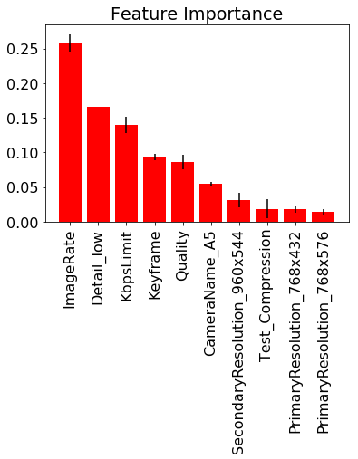

```python
# Feature importances for Extra Trees Regressor
importances = et.feature_importances_
std = np.std([tree.feature_importances_ for tree in et.estimators_],axis=0)
indices = np.argsort(importances)[::-1]
dispindex = np.where(importances[indices] < 0.05*importances[indices][0])[0][0]
importances_trunc = importances[indices][:dispindex]
names_trunc = data_names[indices][:dispindex]
std_trunc = std[indices][:dispindex]
plt.figure()
plt.bar(range(dispindex),importances_trunc,color="r",yerr=std_trunc)
plt.xticks(range(dispindex),names_trunc,rotation='vertical')
plt.title('Feature Importance')
plt.show()
```

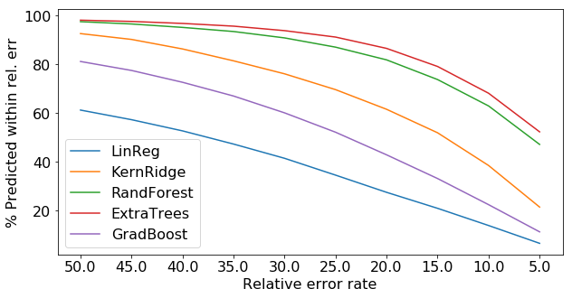

```python
# Look at the cumulative regression performance for each method
p = np.linspace(0.5,0.05,num=10)
def cumul_regress_performance(re,Xtest,Ytest):
    pred = re.predict(Xtest)
    percent = np.zeros(len(p))
    for i in range(len(p)):
        percent[i] = percentHits(Ytest,pred,p[i])
    return percent

regr_methods = [lr,kr,rf,et,gb]
performance = []
for m in regr_methods:
    performance.append(cumul_regress_performance(m,X_test,y_test))
nmethods = len(regr_methods)
ax = plt.figure(figsize=(10,5))
regr_labels = ['LinReg','KernRidge','RandForest','ExtraTrees','GradBoost']
for i in range(nmethods):
    plt.plot(range(len(p)),100*performance[i],label=regr_labels[i])

plt.xlabel('Relative error rate')
plt.ylabel('% Predicted within rel. err')
plt.xticks(range(len(p)),100*p)
plt.legend()
plt.show()
```